# White Wine Quality Exploratory Data Analysis by Zongran Luo

The data set we are going to dig is publicly available for research. The details are described in the following:

P. Cortez, A. Cerdeira, F. Almeida, T. Matos and J. Reis. Modeling wine preferences by data mining from physicochemical properties. In Decision Support Systems, Elsevier, 47(4):547-553. ISSN: 0167-9236.

This data set has 13 variables with 4898 observatons. This data set mainly covered properties of white wines, including index variables, qualities, density and 10 other properties.

The goal of this project is to understand and analyze this data set. In particular, I will try to find answers of the following three questions:

- Find the typical range and distributino of properties and qualities of wines.
- Find the properties that most influence qualities of wines.
- Find relationships between properties and find out if any correlations exist between qualities and properties.

# Univariate Plots Section

I will first take a look at the dimensions, field names and the whole stucture of the data set.

```
## 'data.frame':    4898 obs. of  13 variables:
##  $ X                   : int  1 2 3 4 5 6 7 8 9 10 ...
##  $ fixed.acidity       : num  7 6.3 8.1 7.2 7.2 8.1 6.2 7 6.3 8.1 ...
##  $ volatile.acidity    : num  0.27 0.3 0.28 0.23 0.23 0.28 0.32 0.27 0.3 0.22 ...
##  $ citric.acid         : num  0.36 0.34 0.4 0.32 0.32 0.4 0.16 0.36 0.34 0.43 ...
##  $ residual.sugar      : num  20.7 1.6 6.9 8.5 8.5 6.9 7 20.7 1.6 1.5 ...
##  $ chlorides           : num  0.045 0.049 0.05 0.058 0.058 0.05 0.045 0.045 0.049 0.044 ...
##  $ free.sulfur.dioxide : num  45 14 30 47 47 30 30 45 14 28 ...
##  $ total.sulfur.dioxide: num  170 132 97 186 186 97 136 170 132 129 ...
##  $ density             : num  1.001 0.994 0.995 0.996 0.996 ...
##  $ pH                  : num  3 3.3 3.26 3.19 3.19 3.26 3.18 3 3.3 3.22 ...
##  $ sulphates           : num  0.45 0.49 0.44 0.4 0.4 0.44 0.47 0.45 0.49 0.45 ...
##  $ alcohol             : num  8.8 9.5 10.1 9.9 9.9 10.1 9.6 8.8 9.5 11 ...
##  $ quality             : int  6 6 6 6 6 6 6 6 6 6 ...
```

Our data set consists of 13 variables, with 4898 observations.

From the statement of the data set, each description of variable could be found and I will go through the ditribution of each variable, and this will help us understand the data set better.

Since the first variable, ‘x’, is the index of wine， I will remove this column.

##### Quality Distribution

The quality is from a median of at least 3 evaluations made by wine experts.

**Summary**

```
##    Min. 1st Qu.  Median    Mean 3rd Qu.    Max.
##   3.000   5.000   6.000   5.878   6.000   9.000
```

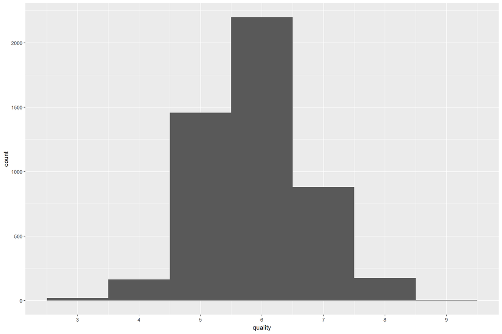

```
##
##    3    4    5    6    7    8    9
##   20  163 1457 2198  880  175    5
```

This variable could be transfered to factor with sequence, so I add quality.discrete to keep quality in the format of factor.

##### Fixed Acidity (gram/liter)

Fixed acidity is most acids involved with wine or fixed or nonvolatile. Its mean and median are very close and the distribution is very normally distributed.

**Summary**

```
##    Min. 1st Qu.  Median    Mean 3rd Qu.    Max.
##   3.800   6.300   6.800   6.855   7.300  14.200
```

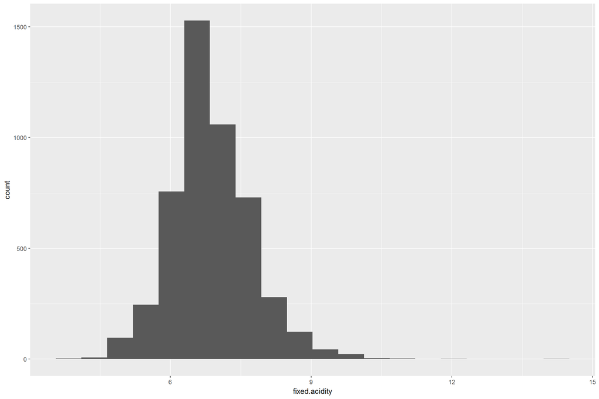

We can see the range is between 3.8 and 14.2, but there are 50% of the data between 6.3 and 7.3. We can see the graph is rather symmetric and normally distributed.

##### Volatile Acidity(gram/liter)

From the statment of data set, I found volatile acidity is the amount of acetic acid in wine, which at too high of levels can lead to an unpleasant, vinegar taste.

**Summary**

```
##    Min. 1st Qu.  Median    Mean 3rd Qu.    Max.
##  0.0800  0.2100  0.2600  0.2782  0.3200  1.1000
```

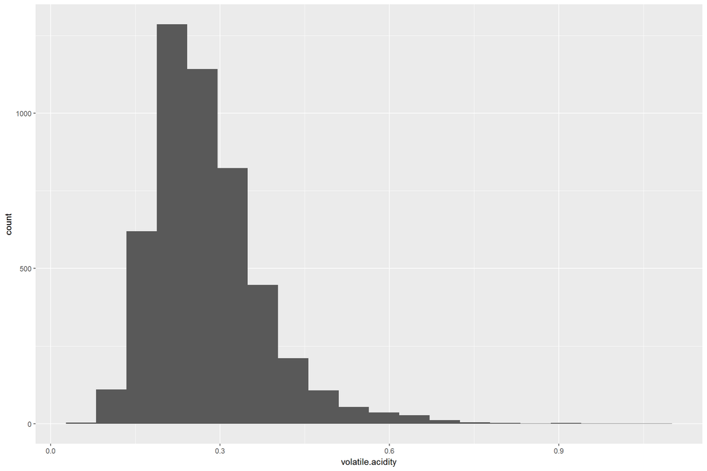

Though we can recognize it is normally distributed, but the graph is positively skewed and I will plot log scale on x axis.

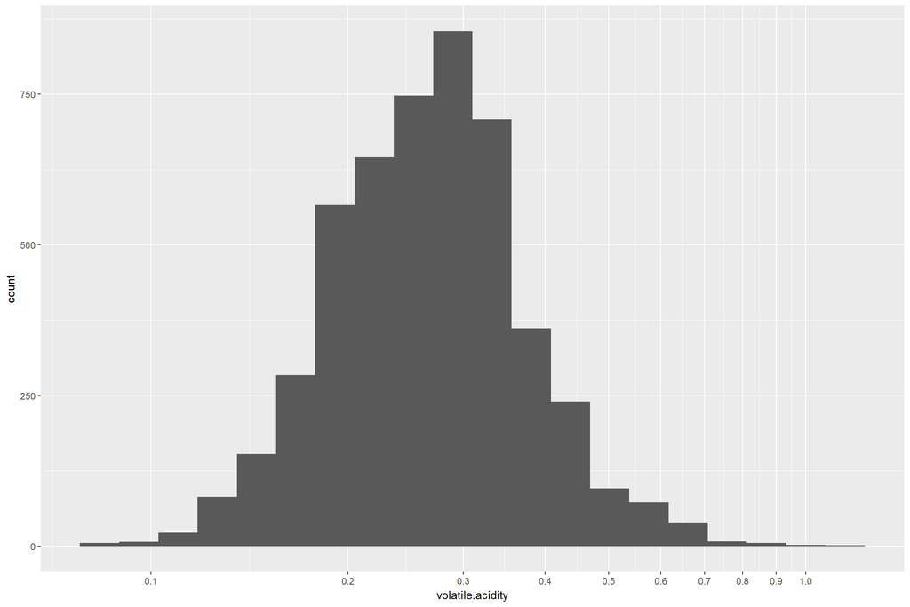

We can see it is more normallized distributed. due to its less density in the lower part, we can see some in the graph with lower acidity are very low or even 0, but it does not affect the distribution.

##### Citric Acid(gram/liter)

From the statment of data set, I found citric acid has small quantities and can add ‘freshness’ and flavor to wines.

**Summary**

```
##    Min. 1st Qu.  Median    Mean 3rd Qu.    Max.
##  0.0000  0.2700  0.3200  0.3342  0.3900  1.6600
```

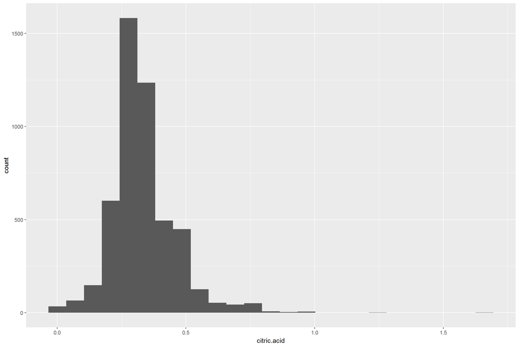

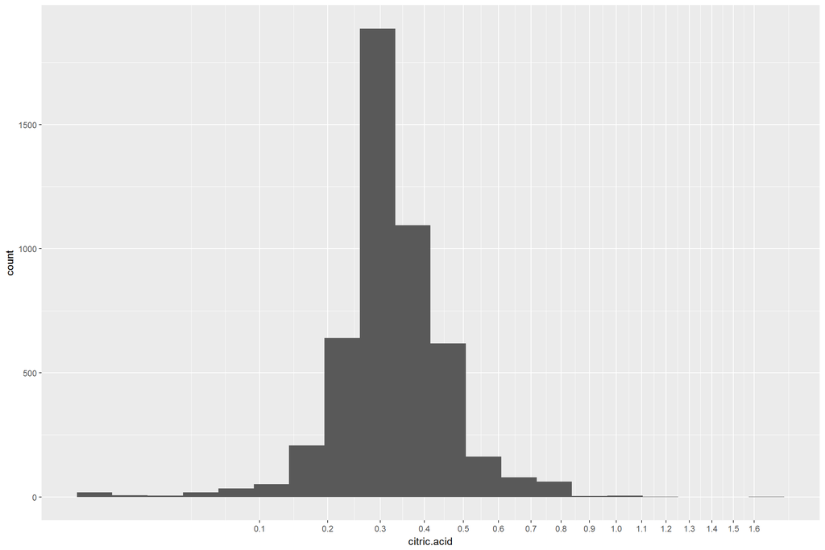

##### Residual Sugar(gram/liter)

From the statment of data set, residual sugar is the amount of sugar remaining after fermentation stops. Wines with less than 1 gram/litter are rare but with more than 45 grams/litter are considered sweet.

**Summary**

```
##    Min. 1st Qu.  Median    Mean 3rd Qu.    Max.
##   0.600   1.700   5.200   6.391   9.900  65.800
```

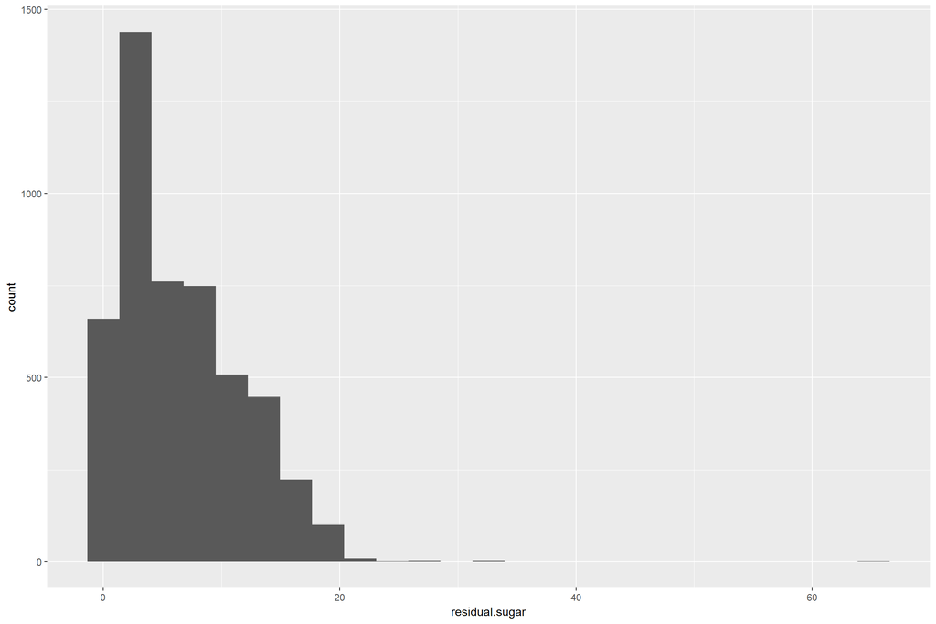

The histogram is positively skewed and so I log the scale of x axis.

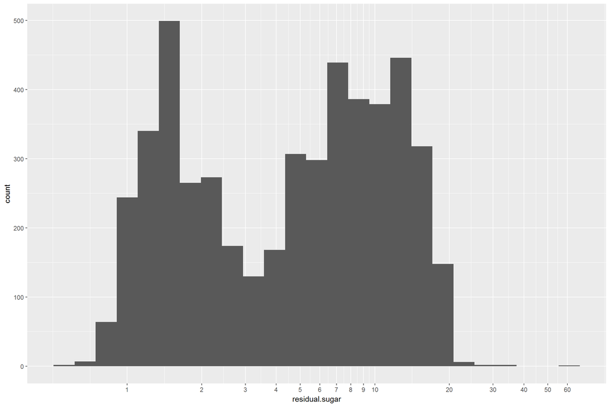

We can see there are two peak for residual sugar, one is between 1 and 2 and the other is between 7 and 15.

Since wines with sugar more than 45 grams/liter are considered sweet, I would create a another categorical variable, “Sweet”, to identify if the wine is sweet or not.

##### Free Sulfur Dioxide and Total Sulfur Dioxide (milligram/liter)

In the statement of the data set, free sulfur dioxide is the free form of SO2 exists in equilibrium between molecular SO2 (as a dissolved gas) and bisulfite; it prevents microbial growth and the oxidation of wine.

Total sulfur dioxide is the amount of free and bound forms of S02; in low concentrations, SO2 is mostly undetectable in wine, but at free SO2 concentrations over 50 mg/L, SO2 becomes evident in the nose and taste of wine.

**Summary**

Free sulfur dioxide

```
##    Min. 1st Qu.  Median    Mean 3rd Qu.    Max.
##    2.00   23.00   34.00   35.31   46.00  289.00
```

Total sulfur dioxide

```
##    Min. 1st Qu.  Median    Mean 3rd Qu.    Max.
##     9.0   108.0   134.0   138.4   167.0   440.0
```

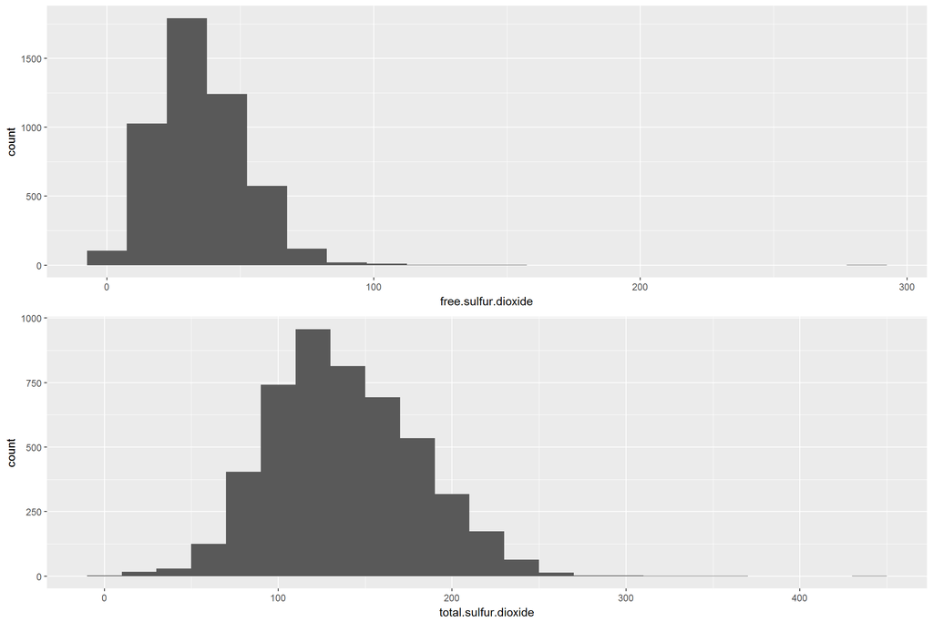

We can see though these two variables are related and both are normally distributed, they seem to not have the same distribution. I will discuss more in the next session.

Since free SO2 will affect nose and taste of wine.I will create a new categorical variable to separate wines which can affect taste with SO2 and the other do not.

##### Sulphates (potassium sulphate - gram / liter)

Sulphates is a wine additive which can contribute to sulfur dioxide gas (S02) levels, which acts as an antimicrobial and antioxidant

**Summary**

```
##    Min. 1st Qu.  Median    Mean 3rd Qu.    Max.
##  0.2200  0.4100  0.4700  0.4898  0.5500  1.0800
```

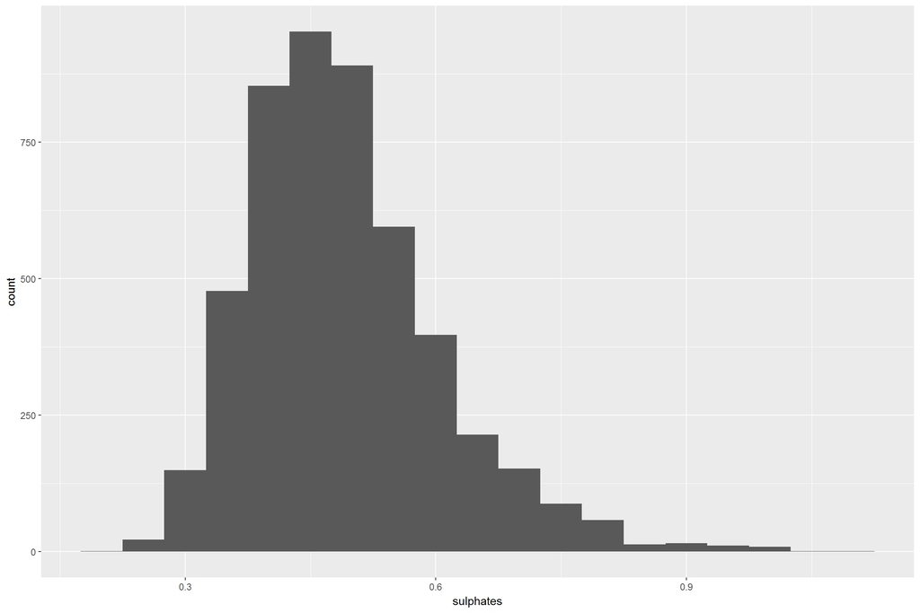

We can see sulphate is normally distributed here.

##### pH

In this data set, pH value describes how acidic or basic a wine is on a scale from 0 (very acidic) to 14 (very basic); most wines are between 3-4 on the pH scale.

**Summary**

```
##    Min. 1st Qu.  Median    Mean 3rd Qu.    Max.
##   2.720   3.090   3.180   3.188   3.280   3.820
```

We can see we have some wines with ph under 3 but no one exceeds 4.

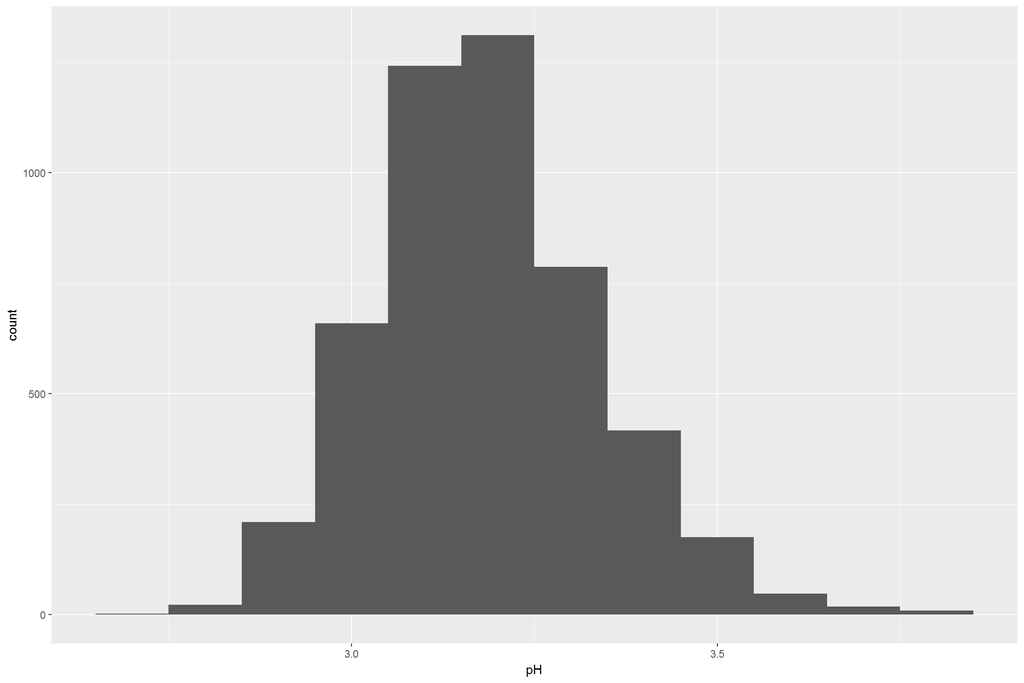

This variable is normally distributed.

##### Density (gram/centimeter^3)

The density of water is close to that of water depending on the percent alcohol and sugar content. **Summary**

```
##    Min. 1st Qu.  Median    Mean 3rd Qu.    Max.
##  0.9871  0.9917  0.9937  0.9940  0.9961  1.0390
```

It is not supprise that the density has a very small range between .9871 and 1.0390. As described in the definition above of density in this data set, it is very close to water depending on its components, alcohol and sugar.

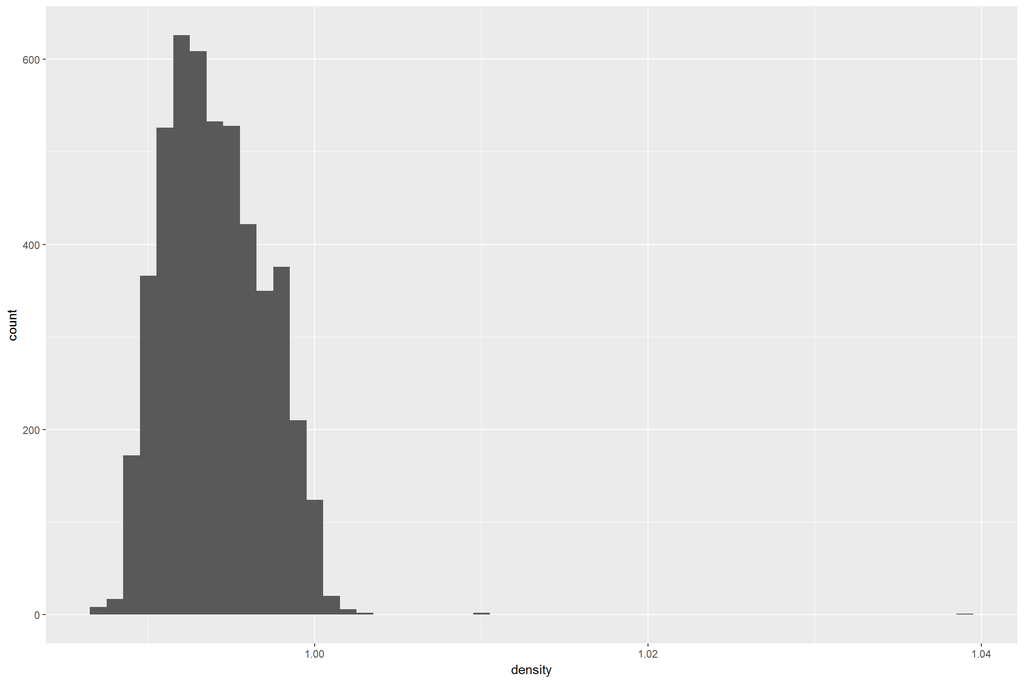

We can see except for some with relatively high density,all of the rest concentrating on the range between .99 to 1.00.

###### Alcohol

In this data set, alcohol is the percent alcohol content of the wine.

**Summary**

```
##    Min. 1st Qu.  Median    Mean 3rd Qu.    Max.
##    8.00    9.50   10.40   10.51   11.40   14.20
```

The alcohol has a distribution between 8% and 14%.

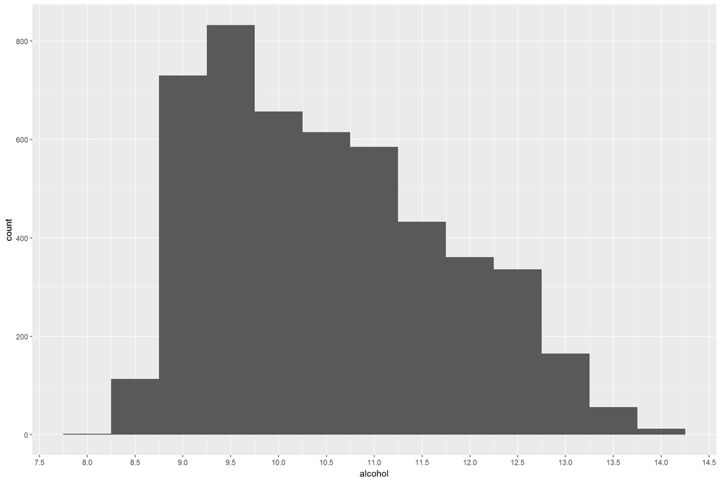

##### Chlorides (gram/liter)

Chlorides are the amount of salt in the wine.

```
##    Min. 1st Qu.  Median    Mean 3rd Qu.    Max.
## 0.00900 0.03600 0.04300 0.04577 0.05000 0.34600
```

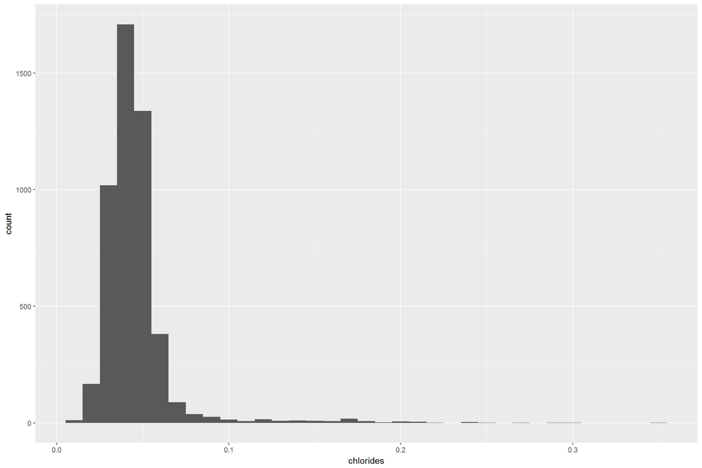

Since the distribution of chlorides has a long tail to the right, I will log the scale of x.

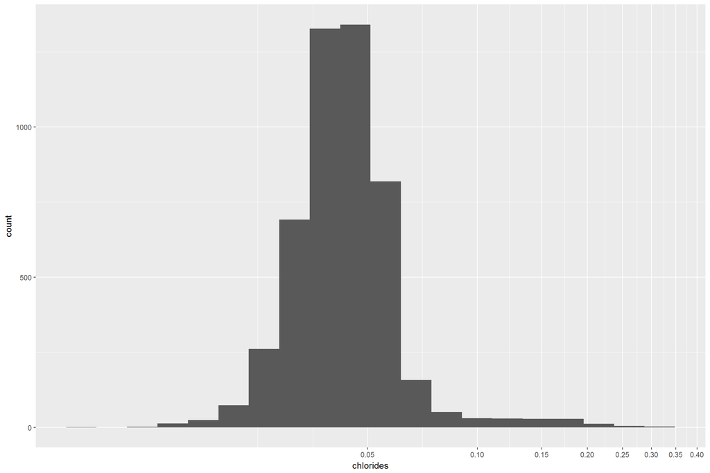

I have made the logarithmic scale for the x axis and we can see that wines generally have chlorides under 0.1g/L.

# Univariate Analysis

### What is the structure of your data set?

This data set has 4898 white wine observations with 13 variables in total, including index variable x, “quality” variable and 11 properties of white wines(fixed acidity, volatile acidity, citric acid, residual sugar, chlorides, free sulfur dioxide, total sulfur dioxide, density, pH, sulphates and alcohol).

The quality is transfered to ordered factor variables with the following levels:

worst —–> best quality: 0,1,2,3,4,5,6,7,8,9,10

Other observations:

- Most features of wines are normally distributed.
- All wines are graded from 3 to 9
- Over 3600 wines were graded with 5 or 6 points.

### What is/are the main feature(s) of interest in your data set?

The main feature of this data set is the quality. 11 properties of wines could all affect the final grade. It looks like the quality could be predictable from these 11 properties.Though a regression model could be created for prediction, we still need to consider correlations between properties.

### What other features in the data set do you think will help support your investigation into your feature(s) of interest?

All other features can support me on the investigation, but we still need to consider correlations and see if we need to eliminate any variables.

### Did you create any new variables from existing variables in the data set?

I created two new categorical variable, SO2.effect and Sweet. SO2.effect is to record wines which have free SO2 concentratoions over 50 ppm and Sweet is to record wines which have sugar over 45 g/L. These wines are considered sweet.

### Of the features you investigated, were there any unusual distributions? Did you perform any operations on the data to tidy, adjust, or change the form of the data? If so, why did you do this?

The original format of the variable of quality is integer, but the quality is a ordered level from 0 to 10, so I transgered it from integers to factors with ordered leveland named it quality.discrete. Therefore, the quality.discrete variabel in the data set is factors with 7 levels from 3 to 9, due to lack of data with quality of 0, 1, 2 and 10.

# Bivariate Plots Section

In this part, I will first make a matrix of plots with the data set of white wine. In this matrix plot, we can find point plots of any two properties and boxplots and bar charts of qualities.

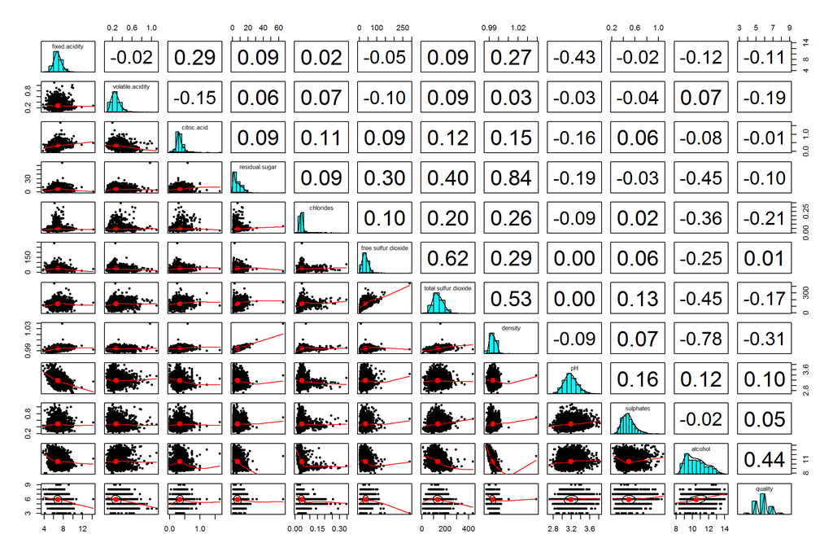

```
##               property1            property2 correlation
## 2               density       residual.sugar   0.8389665
## 3               alcohol              density  -0.7801376
## 4  total.sulfur.dioxide  free.sulfur.dioxide   0.6155010
## 5               density total.sulfur.dioxide   0.5298813
## 6               alcohol       residual.sugar  -0.4506312
## 7               alcohol total.sulfur.dioxide  -0.4488921
## 8               quality              alcohol   0.4355747
## 9                    pH        fixed.acidity  -0.4258583
## 10 total.sulfur.dioxide       residual.sugar   0.4014393
```

I pick the pairs with correlations more than 0.4 and I found some properties are correlated. Density and residual sugar has the correlations of 0.839, while density and alcohol has the correlations of-o.78. Total sulfur dioxide and free sulfur dioxide have the correlations of 0.616.

The higher the residual sugar is, the higher the density will be. On the other hand, the higher the alcohol is, the lower the density will be. That makes sense since alcohol has a lower density while sugar has a higher density. We can also see that total sulful dioxide is positively related to free sulfur dioxide. The wine with more sulful dioxide in total generally wil have more free sulful dioxide.

I want to see how the properties are related to the quality. I will make boxplots for all the properties v.s. quality.

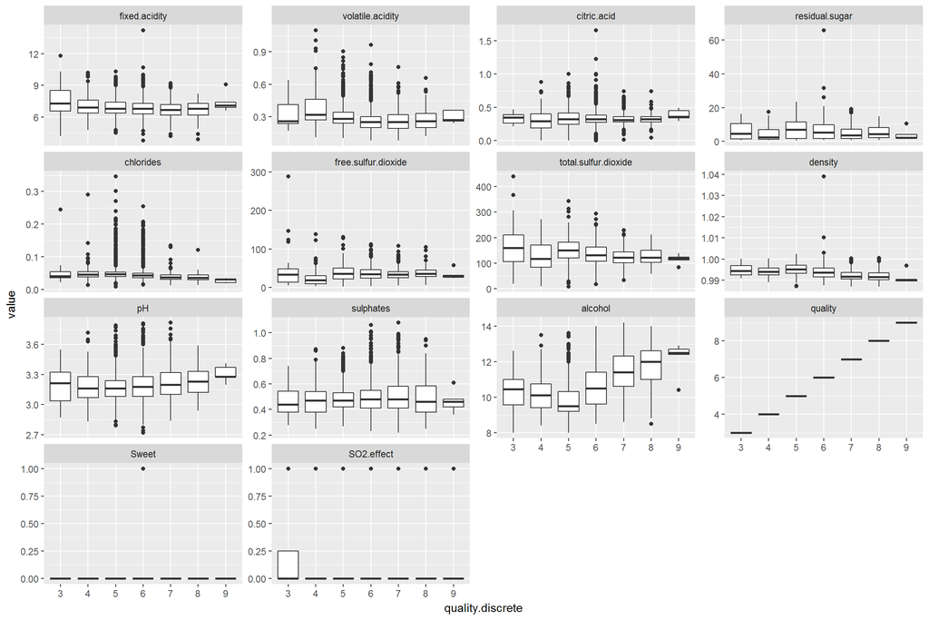

From the boxplot matrix, we can find some trends of qualities.Volatile acidity, free and total sulfur dioxide.

##### pH v.s. Quality

The high quality generally has relatively high pH value. With the quality increasing, we can see the pH value is increasing as well.

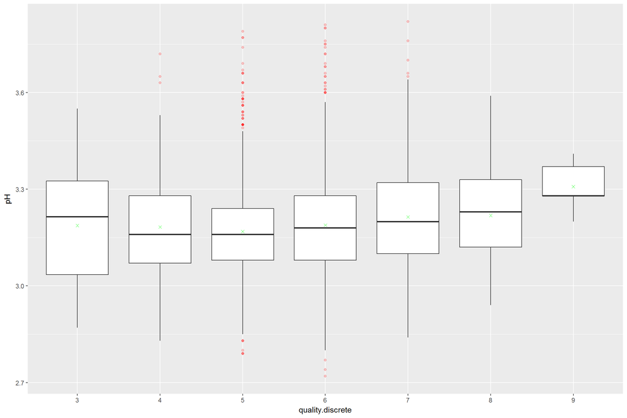

##### Density, Alcohol, Residual Sugar v.s Quality

It looks high quality has a lower density from the graph above, but I will get rid of some outlier to see it more clearly.

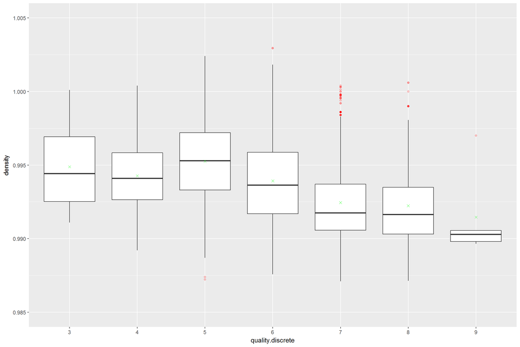

We can see high quality comes with lower density. Since we found density is very related to alcohol and residual sugar, I will see what it looks like if I have alcohol and residual v.s. quality separately.

```
## geom_point: na.rm = FALSE
## stat_summary: na.rm = FALSE, fun.y = function (x, ...)
## UseMethod("mean")
## position_identity
```

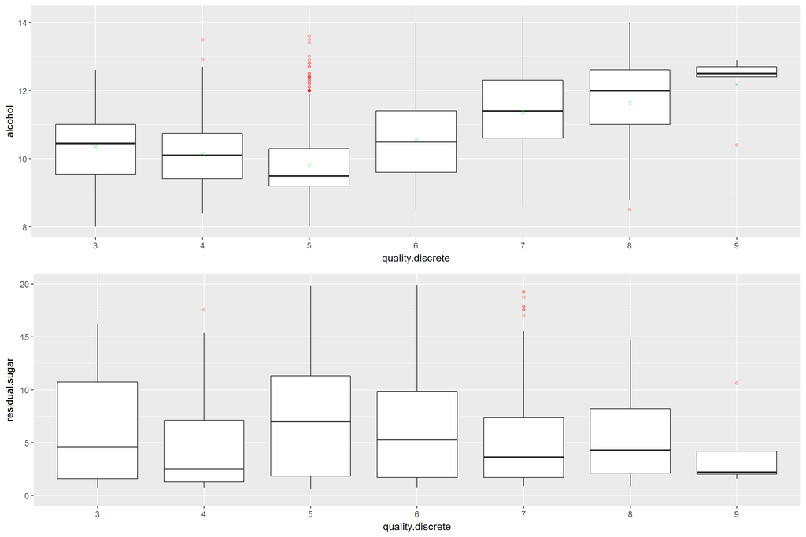

The trend is clear and reflect the correlation of density to alcohol and residual sugar. A wine with high quality generally has higher alcohol and lower residual sugar.

##### Volatile Acidity v.s. Quality

I will create boxplots for each quality to demonstrate volatile acidity of each wine. Red points are outliers and their alpha value is 0.2, and so the darker the part is, the more points there. The green cross is the mean of that category.

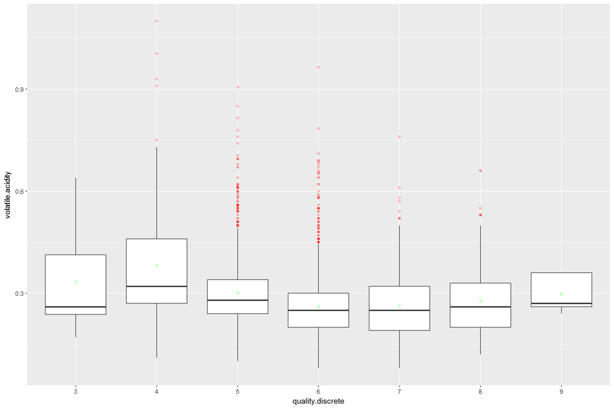

In the boxplots, we can see the medians are around 0.3. But if we see the outliers, we can find the value of outliers, except for the quality of 3, are decreasing while the quality is getting higher.

```
##
##    3    4    5    6    7    8    9
##   20  163 1457 2198  880  175    5
```

Though the quality of 3 has no outliers, it does not mean quality of 3 does not have high volatile acidity. Quality is affected by other properties and in quality of 3, the data set does not have enough size of sample.

##### Free and Total Sulfur Dioxide v.s. Quality

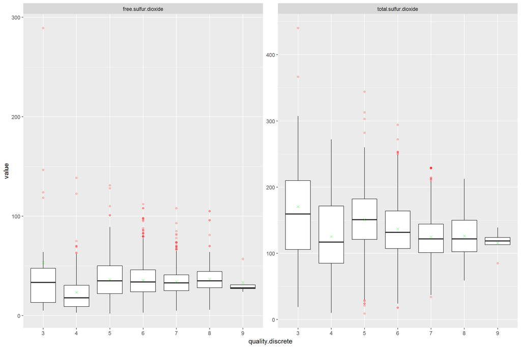

##### Free sulfur dioxide summary

```
## df$quality.discrete: 3
##    Min. 1st Qu.  Median    Mean 3rd Qu.    Max.
##    5.00   13.25   33.50   53.32   47.50  289.00
## --------------------------------------------------------
## df$quality.discrete: 4
##    Min. 1st Qu.  Median    Mean 3rd Qu.    Max.
##    3.00    9.00   18.00   23.36   30.50  138.50
## --------------------------------------------------------
## df$quality.discrete: 5
##    Min. 1st Qu.  Median    Mean 3rd Qu.    Max.
##    2.00   22.00   35.00   36.43   50.00  131.00
## --------------------------------------------------------
## df$quality.discrete: 6
##    Min. 1st Qu.  Median    Mean 3rd Qu.    Max.
##    3.00   24.00   34.00   35.65   46.00  112.00
## --------------------------------------------------------
## df$quality.discrete: 7
##    Min. 1st Qu.  Median    Mean 3rd Qu.    Max.
##    5.00   25.00   33.00   34.13   41.00  108.00
## --------------------------------------------------------
## df$quality.discrete: 8
##    Min. 1st Qu.  Median    Mean 3rd Qu.    Max.
##    6.00   28.00   35.00   36.72   44.50  105.00
## --------------------------------------------------------
## df$quality.discrete: 9
##    Min. 1st Qu.  Median    Mean 3rd Qu.    Max.
##    24.0    27.0    28.0    33.4    31.0    57.0
```

##### Total sulfur dioxide summary

```
## df$quality.discrete: 3
##    Min. 1st Qu.  Median    Mean 3rd Qu.    Max.
##    19.0   105.8   159.5   170.6   210.0   440.0
## --------------------------------------------------------
## df$quality.discrete: 4
##    Min. 1st Qu.  Median    Mean 3rd Qu.    Max.
##    10.0    85.0   117.0   125.3   171.5   272.0
## --------------------------------------------------------
## df$quality.discrete: 5
##    Min. 1st Qu.  Median    Mean 3rd Qu.    Max.
##     9.0   121.0   151.0   150.9   182.0   344.0
## --------------------------------------------------------
## df$quality.discrete: 6
##    Min. 1st Qu.  Median    Mean 3rd Qu.    Max.
##    18.0   107.2   132.0   137.0   164.0   294.0
## --------------------------------------------------------
## df$quality.discrete: 7
##    Min. 1st Qu.  Median    Mean 3rd Qu.    Max.
##    34.0   101.0   122.0   125.1   144.2   229.0
## --------------------------------------------------------
## df$quality.discrete: 8
##    Min. 1st Qu.  Median    Mean 3rd Qu.    Max.
##    59.0   102.5   122.0   126.2   150.0   212.5
## --------------------------------------------------------
## df$quality.discrete: 9
##    Min. 1st Qu.  Median    Mean 3rd Qu.    Max.
##      85     113     119     116     124     139
```

```
## df$quality.discrete: 3
## [1] 104.25
## --------------------------------------------------------
## df$quality.discrete: 4
## [1] 86.5
## --------------------------------------------------------
## df$quality.discrete: 5
## [1] 61
## --------------------------------------------------------
## df$quality.discrete: 6
## [1] 56.75
## --------------------------------------------------------
## df$quality.discrete: 7
## [1] 43.25
## --------------------------------------------------------
## df$quality.discrete: 8
## [1] 47.5
## --------------------------------------------------------
## df$quality.discrete: 9
## [1] 11
```

[output not shown]

# Bivariate Analysis

### Talk about some of the relationships you observed in this part of the investigation. How did the feature(s) of interest vary with other features in the data set?

From the data set, we can find wines with high quality generally have lower density, residual sugar, sulfur dioxide and higher pH value and and alcohol.

### Did you observe any interesting relationships between the other features (not the main feature(s) of interest)?

Density is very related to residual sugar and alcohol. Density has the correlation of 0.84 with sugar and -0.78 with alcohol. More sugar will bring the density up and more alcohol will lower the density. I will discuss it later in multivariate analysis.

### What was the strongest relationship you found?

Among all the correlations, the strongest relationship is density and sugar.That makes sense and more sugar will increase density.

# Multivariate Plots Section

I split the data into 7 plots, which represents 7 different qualities, 3 to 9, in the data set.

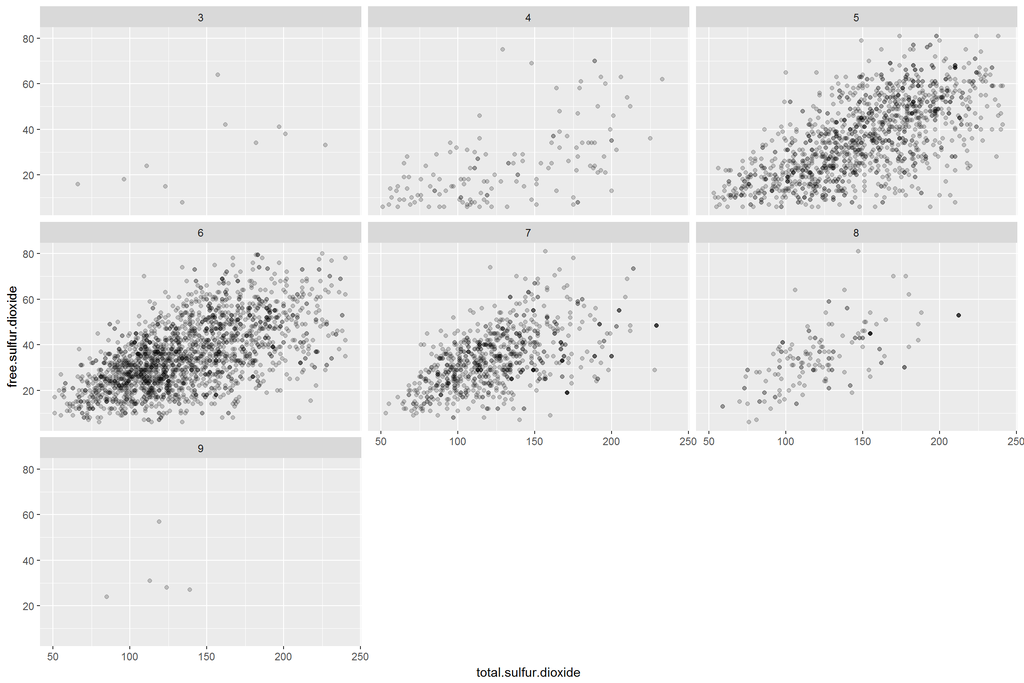

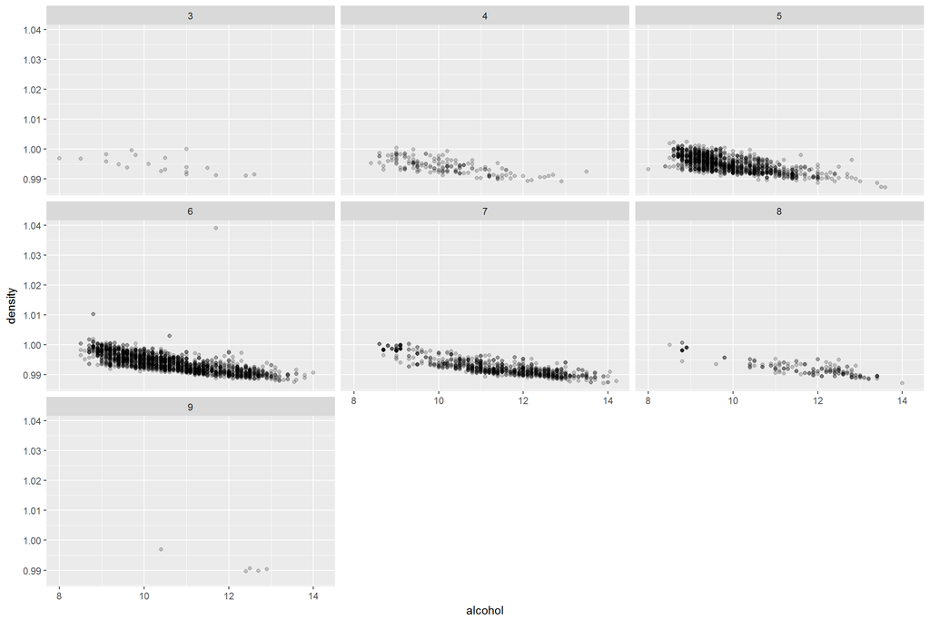

SO2 will influence the taste and smell if free SO2 concerntration is over 50 pps.

```
##   Quality No_SO2effect SO2effect no_so2effectratio
## 1       3           15         5              0.75
## 2       4          149        14              0.91
## 3       5         1108       349              0.76
## 4       6         1808       390              0.82
## 5       7          795        85              0.90
## 6       8          151        24              0.86
## 7       9            4         1              0.80
```

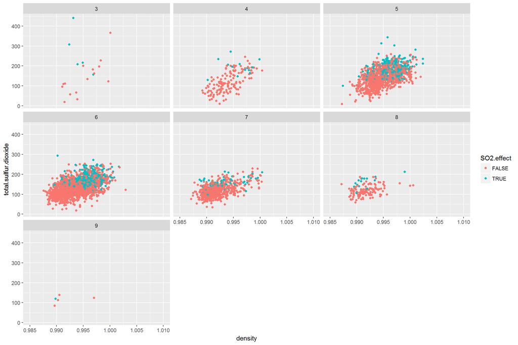

```
##
## Calls:
## m6: lm(formula = quality ~ fixed.acidity + volatile.acidity + citric.acid +
##     residual.sugar + chlorides + free.sulfur.dioxide, data = subset(df,
##     density <= quantile(df$density, 0.999)))
## m7: lm(formula = quality ~ fixed.acidity + volatile.acidity + citric.acid +
##     residual.sugar + chlorides + free.sulfur.dioxide + total.sulfur.dioxide,
##     data = subset(df, density <= quantile(df$density, 0.999)))
## m8: lm(formula = quality ~ fixed.acidity + volatile.acidity + citric.acid +
##     residual.sugar + chlorides + free.sulfur.dioxide + total.sulfur.dioxide +
##     density, data = subset(df, density <= quantile(df$density,
##     0.999)))
## m9: lm(formula = quality ~ fixed.acidity + volatile.acidity + citric.acid +
##     residual.sugar + chlorides + free.sulfur.dioxide + total.sulfur.dioxide +
##     density + pH, data = subset(df, density <= quantile(df$density,
##     0.999)))
## m10: lm(formula = quality ~ fixed.acidity + volatile.acidity + citric.acid +
##     residual.sugar + chlorides + free.sulfur.dioxide + total.sulfur.dioxide +
##     density + pH + sulphates, data = subset(df, density <= quantile(df$density,
##     0.999)))
## m11: lm(formula = quality ~ fixed.acidity + volatile.acidity + citric.acid +
##     residual.sugar + chlorides + free.sulfur.dioxide + total.sulfur.dioxide +
##     density + pH + sulphates + alcohol, data = subset(df, density <=
##     quantile(df$density, 0.999)))
##
## ==================================================================================================
##                            m6         m7          m8           m9           m10          m11
## --------------------------------------------------------------------------------------------------
##   (Intercept)            7.459***   7.528***   254.194***   291.987***   299.961***   226.491***
##                         (0.112)    (0.111)      (8.513)      (8.760)      (8.747)     (23.375)
##   fixed.acidity         -0.118***  -0.100***     0.053***     0.171***     0.176***     0.121***
##                         (0.015)    (0.015)      (0.015)      (0.017)      (0.017)      (0.023)
##   volatile.acidity      -1.553***  -1.336***    -1.860***    -1.842***    -1.820***    -1.873***
##                         (0.123)    (0.124)      (0.116)      (0.113)      (0.113)      (0.114)
##   citric.acid            0.168      0.210*       0.076        0.116        0.063        0.035
##                         (0.107)    (0.106)      (0.098)      (0.096)      (0.095)      (0.096)
##   residual.sugar        -0.014***  -0.007*       0.100***     0.126***     0.131***     0.106***
##                         (0.003)    (0.003)      (0.004)      (0.005)      (0.005)      (0.009)
##   chlorides             -7.863***  -7.034***    -1.793**     -0.157        0.031       -0.032
##                         (0.561)    (0.561)      (0.549)      (0.550)      (0.547)      (0.547)
```

[output cut: 9 more lines]

```
##                                                                           (0.097)      (0.102)
##   alcohol                                                                               0.100***
##                                                                                        (0.030)
## --------------------------------------------------------------------------------------------------
##   R-squared                  0.1        0.1         0.2          0.3          0.3          0.3
##   adj. R-squared             0.1        0.1         0.2          0.3          0.3          0.3
##   sigma                      0.8        0.8         0.8          0.8          0.8          0.7
##   F                         86.2       90.0       197.2        204.8        194.2        178.0
##   p                          0.0        0.0         0.0          0.0          0.0          0.0
##   Log-likelihood         -6104.4    -6053.9     -5665.7      -5567.2      -5531.1      -5525.3
##   Deviance                3473.3     3402.2      2903.1       2788.5       2747.7       2741.2
##   AIC                    12224.8    12125.7     11351.4      11156.3      11086.2      11076.7
##   BIC                    12276.8    12184.2     11416.4      11227.8      11164.1      11161.1
##   N                       4893       4893        4893         4893         4893         4893
## ==================================================================================================
```

None of These models seem to be a good fit. Though the model with all variables has a low p value, which means this model works but it can only explain about 30% of the data, which is still very low. That makes no sense to furthur remove varaibles to get a more precise model. The table is showing models with 6 to 11 variables. None of these models have a good enough adj. R-squared value. Though these models have low p value and variables have some effect but the variability cannot be explained very well due to low R squares.

I found density has high correlations with residual sugar and alcohol. I will try to see if they have any visiable relationships and then create a model.

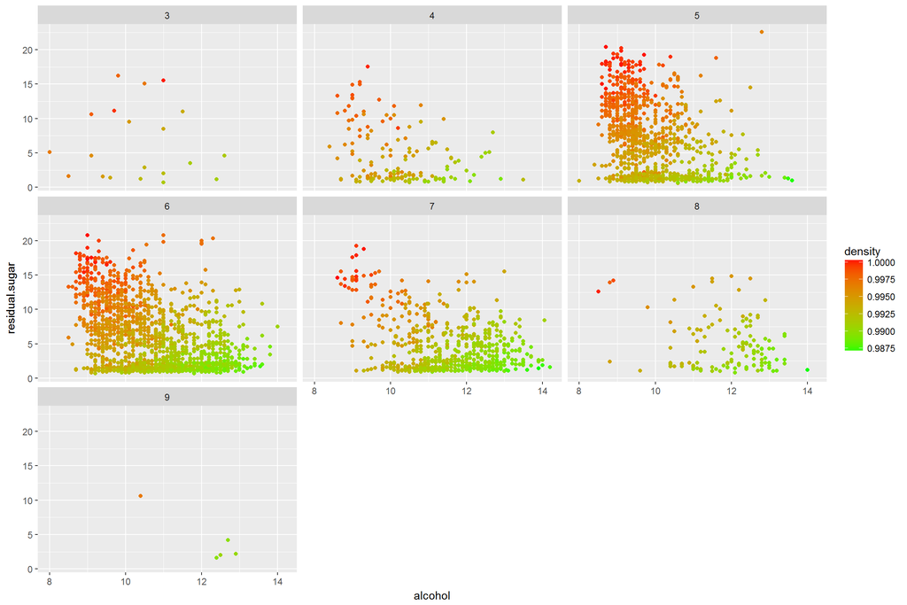

```
##
## Call:
## lm(formula = density ~ alcohol + residual.sugar, data = subset(df,
##     density <= quantile(df$density, 0.999)))
##
## Residuals:
##        Min         1Q     Median         3Q        Max
## -0.0021183 -0.0005799 -0.0001354  0.0004662  0.0043823
##
## Coefficients:
##                  Estimate Std. Error t value Pr(>|t|)
## (Intercept)     1.005e+00  1.236e-04  8130.7   <2e-16 ***
## alcohol        -1.264e-03  1.086e-05  -116.4   <2e-16 ***
## residual.sugar  3.412e-04  2.694e-06   126.6   <2e-16 ***
## ---
## Signif. codes:  0 '***' 0.001 '**' 0.01 '*' 0.05 '.' 0.1 ' ' 1
##
## Residual standard error: 0.0008298 on 4890 degrees of freedom
## Multiple R-squared:  0.9181, Adjusted R-squared:  0.918
## F-statistic: 2.74e+04 on 2 and 4890 DF,  p-value: < 2.2e-16
```

Based on the r-squared, alcohol and residual.sugar can explain 91.8 percent of the variance in density.

# Multivariate Analysis

### Talk about some of the relationships you observed in this part of the investigation. Were there features that strengthened each other in terms of looking at your feature(s) of interest?

I found quality would increase with density going down.I found a high SO2 may affect the tatse and smell of wines and so I assumed it might affect the quality. I created a variable, SO2effect, which recorded if wines have free SO2 over 50 ppm which might affect the taste of wines. However, from the table of SO2 and quality. A trend cannot be seen by looking the no_so2effect in the table. I assumed that it should be getting higher with higher qualities, but the fact is that is not the trend. It looks like smell and taste from SO2 do not influence the quality alone.

### Were there any interesting or surprising interactions between features?

For other features, I try to test alcohol with density and alcohol. As I expected earlier, alcohol is very realted to density and alcohol and the model can help the model of density to explain 91 percent of the data.

### OPTIONAL: Did you create any models with your data set? Discuss the strengths and limitations of your model.

I created two models of regression, one for the quality and the other for density. The model of quality cannot explain the variability effectively due to a low R square. However, the model of density can explain 91 percent of the variability and this is a good model.

# Final Plots and Summary

### Plot One

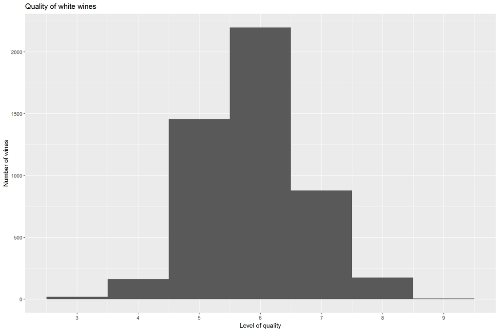

### Plot Two

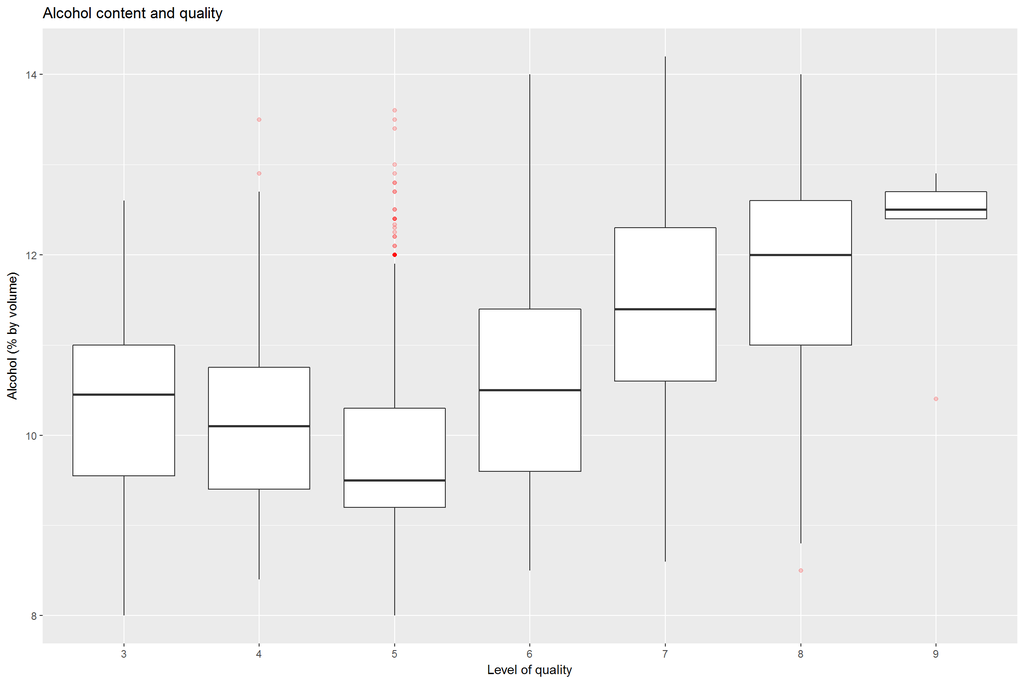

### Description Two

We can see that generally quality of wines increase when alcohol increases. However, these trends are not very clear since we still have exceptions in the sample of wines with quality 4 and 3. The medians go down from wines with quality 3 to wines with quality 5.

### Plot Three

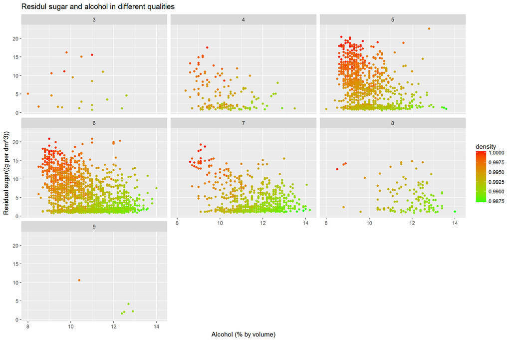

### Description Three

The plots are splitted in qualities. We can find wines with high quality have more alcohol comparing to residual sugar, and wines with lower quality have more sugar instead. Also, we did not find many wines on the top right. It means wines having high alcohol barely have high sugar.

# Reflection

The data set contains information on 4898 lines across 13 variables. I started by understanding the individual variables in the data set and then I explored bivariated plots and find correlations between variabales. Eventually, I explored the quality across multiple variables and created a linear model to predict wine qualities.

This data set has 1 index, 1 quality and 11 properties. I was supprised 10 out of 11 properties were normally distributed. Every property has some relationship with quality, but the linearity is not clear. The most clear trend with quality I can find is alcohol. Quality has the positive linearity with alcohol, but the trend does not work for wines with low quality. Also It was not supprised to see that density has high correlations with residual sugar and alcohol. Generally, the linear model for quality does not have clear trend and cannot explain the variability of the properties.

Limitations of this model include the source of data. We find the distribution of quality is normally distributed. It means the data set does not have enough sample in of wines with lowest quality and highest quality. However, I mainly used boxplot to see the range of data and the median for each quality. A general trendo of quality could still be found. It is hard to find a linear model between variables and quality.

Also methodology is another limit since from what I observe, quality might not be linearly related to current variables. We can have some discriptive summary here, but if we want to go for predictions, we might need to use machine learning which might be more helpful in predictions. However, in terms of density, I successfully find out a regression model with low p value and high R square value. Ths model is to predict density with residual sugar and alcohol. That makes sense since more alcohol lead to lower density and more sugar lead to high density.